# 101.1. Alert retrieval service

For the Rubin Science Platform at data.lsst.cloud.  
Data Release: [Prompt Products](https://prompt-products.lsst.io/)  
Container Size: Large  
LSST Science Pipelines version: r29.2.0  
Last verified to run: 2026-06-17  
Repository: github.com/lsst/tutorial-notebooks  
DOI: 10.11578/rubin/dc.20250909.20

**Learning objective:** How to obtain single alert packets from the RSP's alert retrieval service.

**LSST data products:** Alert packets.

**Packages:** `lsst.rsp.RSPClient`, `lsst.rsp.get_service_url`, `fastavro`.

**Credit:** Originally developed by Rubin Data Management team members. Please consider acknowledging them if this notebook is used for the preparation of journal articles, software releases, or other notebooks.

**Get Support:** Everyone is encouraged to ask questions or raise issues in the [Support Category](https://community.lsst.org/c/support) of the Rubin Community Forum. Rubin staff will respond to all questions posted there.

## 1. Introduction

The RSP's alert retrieval service enables the contents of single alert packets to be retrieved by alert ID number, in one of three formats: Avro, JSON, or FITS. See also the technical note "Design of an Alert Retrieval Service in the RSP" ([SQR-114](https://sqr-114.lsst.io/)).

**Alert packets** are files of measurements for sources detected in difference images that are streamed to brokers within a few minutes of image acquisition. Alerts are a Prompt Product, and are the result of Rubin's Difference Image Analysis (DIA) and Alert Production (AP) pipelines.

**Brokers** are the recommended way to do time-domain science with alerts because their functionality includes, e.g., filtering, cross-match, and classification, and users can explore and retrieve scientifically-relevant subsets via their web-based user interfaces or API clients.

**Why use the RSP's alert retrieval service?**  
The alert retrieval service is useful when only the contents of a single alert packet are desired, and the alert ID is known. Otherwise, brokers are the best way to do real-time science with the alerts, and scientific analyses on longer timescales (days to weeks) can use the other Prompt Products (queryable databases, images).

**Additional resources:**

- [Alert Production database schema](https://sdm-schemas.lsst.io/apdb.html).
- [Prompt Products documentation](https://prompt-products.lsst.io/).
- [Learn more about the LSST alert brokers](https://rubinobservatory.org/for-scientists/data-products/alerts-and-brokers).

**This tutorial** focuses on how the alert retrieval service works, and options for packet retrieval formats (e.g., FITS, JSON, schema-only, cutouts-only).

**Related tutorials:** The 200-level tutorial on alert packets focuses on the details of the packets' schema and data contents, and how packets for static-sky and moving objects differ.

### 1.1. Import packages

Import the `fastavro` package for reading alerts in the default Avro format. Import the `base64` package for reading image stamps in the JSON format. Import the `RSPClient` and `get_service_url` in order to access the alert retrieval service. Also import a range of other plotting and analyis packages.

```python
import fastavro
import base64
import matplotlib.pyplot as plt
import numpy as np
import pandas as pd
import io
from astropy.io import fits
from astropy.nddata import CCDData
from astropy.visualization import (MinMaxInterval, LinearStretch,
                                   ImageNormalize)

from lsst.rsp import RSPClient, get_service_url
from lsst.utils.plotting import (get_multiband_plot_colors,
                                 get_multiband_plot_symbols)
```

### 1.2. Define parameters and functions

Establish the connection to the alert retrieval service by getting the `url` for the service and instantiating the `RSPClient`.

```python
url = get_service_url("alerts", "prompt")
client = RSPClient("")
```

Use the recommended colorblind-friendly palette to represent Rubin filters.

```python
filter_colors = get_multiband_plot_colors()
filter_names = list(filter_colors.keys())
filter_symbols = get_multiband_plot_symbols()
```

The alert used in this tutorial has an alert id = 170059317401616524, which matches the `diaSourceId` of the triggering `DiaSource`. Note that the alert retrieval service will also accept IAU-formatted IDs in the form of: LSST-AP-DS-170059317401616524, where the numerical portion is the `diaSourceId`. The alert was selected from the [ALeRCE broker](https://lsst.alerce.online/object/170059286935240883?survey=lsst).

```python
alert_id = "170059317401616524"
```

## 2. Avro format

An Avro Object Container File (OCF) is the default response format from the alert retrieval service and has the same format as the originally-transmitted alert packet.

### 2.1. Full packet

Retrieve the full packet using the `await` command to ensure a response is returned before moving on.

```python
response = await client.get(url, params={"ID": alert_id})
response.raise_for_status()
response?
```

```
Type:        Response
String form: <Response [200 OK]>
File:        /opt/lsst/software/stack/conda/envs/lsst-scipipe-10.1.0-exact/lib/python3.12/site-packages/httpx/__init__.py
Docstring:   <no docstring>
```

Read the packet with the `fastavro.reader`. Get the schema that is embedded in the packet. Print only the keys, with an option to display the full schema.

```python
packet = fastavro.reader(io.BytesIO(response.content))
schema = packet.writer_schema
print(f"Schema keys: {schema.keys()}")
# schema
```

```
Schema keys: dict_keys(['type', 'name', 'fields'])
```

Get the packet record and print the keys.

```python
records = list(packet)
record = records[0]
print(f"Record keys: {record.keys()}")
```

```
Record keys: dict_keys(['diaSourceId', 'observation_reason', 'target_name', 'diaSource', 'prvDiaSources', 'prvDiaForcedSources', 'diaObject', 'ssSource', 'mpc_orbits', 'cutoutDifference', 'cutoutScience', 'cutoutTemplate'])
```

Print the values for the first three keys.

```python
print(f" diaSourceId         {record['diaSourceId']}")
print(f" observation_reason  {record['observation_reason']}")
print(f" target_name         {record['target_name']}")
```

```
 diaSourceId         170059317401616524
 observation_reason  alert_cosmos
 target_name         ddf_cosmos, lowdust
```

#### 2.1.1. Triggering source

For the triggering `diaSource` record, print the band (filter), MJD (date and time at the midpoint of the exposure), and the difference-image flux and its error in nJy.

```python
diaSource = record['diaSource']
print(f" Band   {diaSource['band']}")
print(f" MJD    {diaSource['midpointMjdTai']}")
print(f" Flux   {diaSource['psfFlux']}")
print(f" Error  {diaSource['psfFluxErr']}")
```

```
 Band   i
 MJD    61097.322050417104
 Flux   -3602.8203125
 Error  313.1190185546875
```

#### 2.1.2. Lightcurve

Extract the band, MJD, and PSF difference-image fluxes from the alert record as `numpy` arrays, and plot the lightcurve.

Begin by extracting the `diaSource` and previous diaSource (`prvDiaSources`) measurements to pandas dataframes, then concatenate them into a single dataframe.

```python
df = pd.DataFrame(record['diaSource'], index=[0])
df_prv = pd.DataFrame(record['prvDiaSources'])
df_all = pd.concat([df, df_prv], ignore_index=True)
```

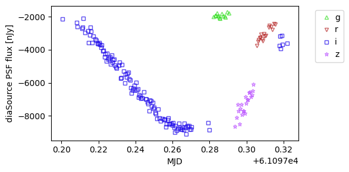

```python
fig = plt.figure(figsize=(6, 3))
for f, filt in enumerate(filter_names):
    df_pick_band = df_all.loc[df_all['band'] == filt]
    if len(df_pick_band) > 0:
        plt.plot(df_pick_band['midpointMjdTai'], df_pick_band['psfFlux'], filter_symbols[filt], ms=5, mew=1,
                 alpha=0.7, mec=filter_colors[filt], color='None', label=filt)

plt.xlabel('MJD')
plt.ylabel('diaSource PSF flux [nJy]')
plt.legend(bbox_to_anchor=(1.05, 1), handletextpad=0, loc='upper left')
plt.tight_layout()
plt.show()
```

> **Figure 1:** The PSF difference-image flux lightcurve.

#### 2.1.3. Image stamps

Extract and display the three image stamps (cutouts) from the packet record.

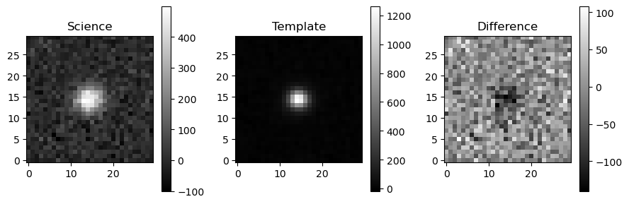

```python
stamps = [record['cutoutScience'],
          record['cutoutTemplate'],
          record['cutoutDifference']]
stamp_names = ['Science', 'Template', 'Difference']

fig, ax = plt.subplots(1, 3, figsize=(9, 3))
for s, (stamp, name) in enumerate(zip(stamps, stamp_names)):
    hdul = fits.HDUList.fromstring(stamp)
    data = hdul[0].data
    image = CCDData(data.astype("float32"), unit='nJy')
    norm = ImageNormalize(image, interval=MinMaxInterval(),
                          stretch=LinearStretch())
    plt.sca(ax[s])
    plt.imshow(image, origin='lower', norm=norm, cmap='gray')
    plt.colorbar()
    ax[s].set_title(name)
plt.tight_layout()
plt.show()
```

> **Figure 2:** The science, template, and difference-image stamps.

Clear all the data used above.

```python
del response, packet, schema, records, record
del diaSource, stamps, stamp_names
```

#### 2.1.4. Associated object

The record also contains the `diaObject` (for static-sky time-variable objects) or the `ssSource` and `mpc_orbits` (for moving objects in the Solar System).

### 2.2 Schema only

It is usually not necessary to retrieve the alert schema on its own, as the schema are embedded in the packet as demonstrated above.

However, if there is a need for schema only, this is how to get it.

```python
response = await client.get(f"{url}/schema", params={"ID": alert_id})
response.raise_for_status()
```

```
<Response [200 OK]>
```

Avro schemas are written in JSON, so use the `response.json()` method to convert to a Python dict in order to explore.

```python
schema = response.json()
```

Print some fields from the schema.

```python
print(f"Schema name: {schema['name']}")
print(f"Schema namespace: {schema['namespace']}")
print(f"Top-level fields: {[f['name'] for f in schema['fields']]}")
```

```
Schema name: alert
Schema namespace: lsst.v10_0
Top-level fields: ['diaSourceId', 'observation_reason', 'target_name', 'diaSource', 'prvDiaSources', 'prvDiaForcedSources', 'diaObject', 'ssSource', 'mpc_orbits', 'cutoutDifference', 'cutoutScience', 'cutoutTemplate']
```

Option to enumerate the fields and then extract the schema for field `diaSource`, containing the measurements for the detection in the difference-image that triggered the alert to be produced.

Alternatively, [browse the alert schema](https://sdm-schemas.lsst.io/apdb.html) online.

```python
# fields = schema['fields']
# for f, field in enumerate(fields):
#     print(f, field['name'])
# diaSource = fields[3]
# diaSource
# del fields, diaSource
```

Clear the data used above.

```python
del response, schema
```

### 2.3. Stamps only

If only the image stamps (cutouts) from an alert are desired, have the alert retrieval service only return the images in the response.

```python
response = await client.get(f"{url}/cutouts", params={"ID": alert_id})
response.raise_for_status()
```

```
<Response [200 OK]>
```

Display the three image stamps.

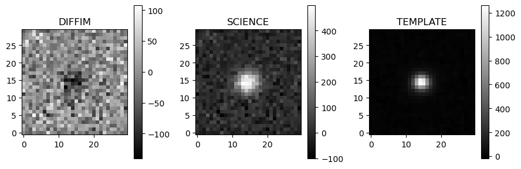

```python
stamps = fits.open(io.BytesIO(response.content))
stamp_names = [hdu.name for hdu in stamps if hdu.name != "PRIMARY"]

fig, axes = plt.subplots(1, len(stamp_names), figsize=(3 * len(stamp_names), 3))
if len(stamps) == 1:
    axes = [axes]
for ax, name in zip(axes, stamp_names):
    image = CCDData(stamps[name].data.astype("float32"), unit='nJy')
    norm = ImageNormalize(image, interval=MinMaxInterval(),
                          stretch=LinearStretch())
    plt.sca(ax)
    plt.imshow(image, origin='lower', norm=norm, cmap='gray')
    plt.title(name)
    plt.colorbar()
plt.tight_layout()
plt.show()
```

> **Figure 3:** The difference-image, science, and template stamps.

Clear the data used above.

```python
del response, stamps, stamp_names
```

## 3. JSON format

The JSON response is the full deserialized alert record. Request the JSON formatted response by using the `RESPONSEFORMAT` keyword.

```python
response = await client.get(url, params={"ID": alert_id, "RESPONSEFORMAT": "json"})
response.raise_for_status()
```

```
<Response [200 OK]>
```

```python
record = response.json()
print(f"Top-level keys: {list(record.keys())}")
```

```
Top-level keys: ['diaSourceId', 'observation_reason', 'target_name', 'diaSource', 'prvDiaSources', 'prvDiaForcedSources', 'diaObject', 'ssSource', 'mpc_orbits', 'cutoutDifference', 'cutoutScience', 'cutoutTemplate']
```

Print a few properties of the triggering difference-image source record, `diaSource`.

```python
diaSource = record['diaSource']
print(f" Band   {diaSource['band']}")
print(f" MJD    {diaSource['midpointMjdTai']}")
print(f" Flux   {diaSource['psfFlux']}")
print(f" Error  {diaSource['psfFluxErr']}")
```

```
 Band   i
 MJD    61097.322050417104
 Flux   -3602.8203125
 Error  313.1190185546875
```

Option to plot the lightcurve. The code is exactly the same as for the Avro packet.

```python
# df = pd.DataFrame(record['diaSource'], index=[0])
# df_prv = pd.DataFrame(record['prvDiaSources'])
# df_all = pd.concat([df, df_prv], ignore_index=True)

# fig = plt.figure(figsize=(6, 3))
# for f, filt in enumerate(filter_names):
#     df_pick_band = df_all.loc[df_all['band'] == filt]
#     if len(df_pick_band) > 0:
#         plt.plot(df_pick_band['midpointMjdTai'], df_pick_band['psfFlux'], filter_symbols[filt], ms=5, mew=1,
#                  alpha=0.7, mec=filter_colors[filt], color='None', label=filt)

# plt.xlabel('MJD')
# plt.ylabel('diaSource PSF flux [nJy]')
# plt.legend(bbox_to_anchor=(1.05, 1), handletextpad=0, loc='upper left')
# plt.tight_layout()
# plt.show()
```

Option to display the stamps. The code is very similar to that used for the Avro packets, except in the JSON formatted packet the image stamps are base64-encoded bytes. They need to be first decoded with `base64.b64decode` then read as bytes with `io.BytesIO` by `fits.open`. Note also that the stamps are in a different order than in the Avro packets.

```python
# stamps = [base64.b64decode(record.get("cutoutDifference")),
#           base64.b64decode(record.get("cutoutScience")),
#           base64.b64decode(record.get("cutoutTemplate"))]
# stamp_names = ['Difference', 'Science', 'Template', ]

# fig, ax = plt.subplots(1, 3, figsize=(9, 3))
# for s, (stamp, name) in enumerate(zip(stamps, stamp_names)):
#     hdul = fits.open(io.BytesIO(stamp))
#     data = hdul[0].data
#     image = CCDData(data.astype("float32"), unit='nJy')
#     norm = ImageNormalize(image, interval=MinMaxInterval(),
#                           stretch=LinearStretch())
#     plt.sca(ax[s])
#     plt.imshow(image, origin='lower', norm=norm, cmap='gray')
#     plt.colorbar()
#     ax[s].set_title(name)
# plt.tight_layout()
# plt.show()
# del stamps, stamp_names
```

Clear the data used above.

```python
del response, record, diaSource
```

## 4. FITS format

The FITS response is a multi-extension file with the following extensions.

- `PRIMARY`: A header with telescope and instrument.
- `ALERT`: Data from the associated DIA (static-sky) or SS (moving) object.
- `DIFFIM`, `SCIENCE`, and `TEMPLATE`: Image stamps (cutouts).
- `DIASOURCE`: The triggering source record (row 0), plus any prior source records.
- `FORCEDPHOT`: Any prior forced-photometry measurements.
- `SSSOURCE`: Any associated solar system source records.

While these extensions are the same for all packets, the schema (columns) and data in the `ALERT`, `DIASOURCE`, and `SSSOURCE` extensions depend on whether the alert-triggering detection is associated with a `diaObject` (static-sky transient or variable) or an `ssObject` (moving object).

Get the alert packet in FITS format.

```python
response = await client.get(url, params={"ID": alert_id, "RESPONSEFORMAT": "fits"})
response.raise_for_status()
```

```
<Response [200 OK]>
```

Use the `fits` package to open the content of `response` into a Header Data Unit List (HDUL), and print the names of each header.

```python
hdul = fits.open(io.BytesIO(response.content))
for hdu in hdul:
    print(hdu.name)
```

```
PRIMARY
ALERT
DIFFIM
SCIENCE
TEMPLATE
DIASOURCE
FORCEDPHOT
SSSOURCE
```

**PRIMARY**  
The primary extension contains only header information about the telescope and instrument, and no data. Show the primary header for the `hdul`.

```python
hdu = hdul['PRIMARY']
hdu.header
```

```
SIMPLE  =                    T / conforms to FITS standard
BITPIX  =                    8 / array data type
NAXIS   =                    0 / number of array dimensions
EXTEND  =                    T
TELESCOP= 'Rubin Observatory'
INSTRUME= 'LSSTCam '
```

Clean up.

```python
del hdu
```

**DIFFIM, SCIENCE, TEMPLATE**  
Option to display the image stamp "triplet" of science, template, and difference image for the `hdul`.

```python
# fig, ax = plt.subplots(1, 3, figsize=(9, 3))
# for i, ext in enumerate(["SCIENCE", "TEMPLATE", "DIFFIM"]):
#     image = CCDData(hdul[ext].data.astype("float32"), unit='nJy')
#     norm = ImageNormalize(image, interval=MinMaxInterval(),
#                           stretch=LinearStretch())
#     plt.sca(ax[i])
#     plt.imshow(image, origin='lower', norm=norm, cmap='gray')
#     plt.colorbar()
#     ax[i].set_title(ext)
# plt.tight_layout()
# plt.show()
```

**ALERT**  
The `ALERT` HDU contains data from the associated static-sky object (`diaObject`) or moving object (`ssObject`). The particular alert chosen in Section 1.2 is a static-sky variable, and the `ALERT` extension contains `diaObject` columns. Alerts for moving objects have different columns in the `ALERT` extension.

Option to get the `ALERT` extension HDU for the static-sky packet from `hdul`, and print the number of columns, and a few key column values.

```python
# hdu = hdul['ALERT']
# print(len(hdu.columns))
# data = hdu.data
# columns = ["diaSourceId", "observation_reason", "target_name"]
# for col in columns:
#     print(f"{col:<20} {data[col][0]}")
# del data, columns, hdu
```

**DIASOURCE**  
The `DIASOURCE` extension contains data for the triggering `diaSource` (row 0) and all previous detections (the lightcurve).

Option to extract the `diaSource` data and plot the lightcurve.

```python
# hdu = hdul['DIASOURCE']
# data = hdu.data
# fig = plt.figure(figsize=(6, 3))
# for f, filt in enumerate(filter_names):
#     fx = np.where(data['band'] == filt)[0]
#     if len(fx) > 0:
#         plt.plot(data['midpointMjdTai'][fx], data['psfFlux'][fx], filter_symbols[filt], ms=5,
#                  mew=1, alpha=0.7, mec=filter_colors[filt], color='None', label=filt)
#     del fx
# plt.xlabel('MJD')
# plt.ylabel('difference-image PSF flux [nJy]')
# plt.legend(bbox_to_anchor=(1.05, 1), handletextpad=0, loc='upper left')
# plt.tight_layout()
# plt.show()
# del data
# del hdu
```

**FORCEDPHOT**

The `FORCEDPHOT` extension contains forced measurement data on all previous visits at the position of the `diaSource` (the lightcurve). This includes measurements on the difference images and the science images.

Option to extract the `diaSource` data and plot the forced photometry lightcurve.

```python
# hdu = hdul['FORCEDPHOT']
# data = hdu.data
# fig = plt.figure(figsize=(6, 3))
# for f, filt in enumerate(filter_names):
#     fx = np.where(data['band'] == filt)[0]
#     if len(fx) > 0:
#         plt.plot(data['midpointMjdTai'][fx], data['psfFlux'][fx], filter_symbols[filt], ms=5,
#                  mew=1, alpha=0.7, mec=filter_colors[filt], color='None', label=filt)
#     del fx
# plt.xlabel('MJD')
# plt.ylabel('forced difference-image flux [nJy]')
# plt.legend(bbox_to_anchor=(1.05, 1), handletextpad=0, loc='upper left')
# plt.tight_layout()
# plt.show()
# del data
# del hdu
```

**SSSOURCE**

The `SSSOURCE` extension contains the LSST-computed per-source instantaneous quantities at the time of observation (e.g., heliocentric and topocentric positions and velocities) for alerts associated with moving objects (i.e., Solar System objects).

Using an ID of a known Solar System object (SSO), retrieve the `SSSOURCE` information.

```python
sso_alert_id = "170059294376985743"
```

```python
sso_response = await client.get(url, params={"ID": sso_alert_id, "RESPONSEFORMAT": "fits"})
sso_response.raise_for_status()
sso_hdul = fits.open(io.BytesIO(sso_response.content))
for hdu in sso_hdul:
    print(hdu.name)
```

```
PRIMARY
ALERT
DIFFIM
SCIENCE
TEMPLATE
DIASOURCE
FORCEDPHOT
SSSOURCE
```

Note that the header cards are the same for all alerts. However, this alert will have data in the `SSSOURCE` extension. Extract that extension, and examine the `ssObjectId` of the alert.

```python
hdu = sso_hdul['SSSOURCE']
sso_data = hdu.data
print(sso_data['ssObjectId'])
```

```
[21163646022202707]
```

Option to list the names of all the columns in `SSSOURCE`.

```python
# for col in sso_hdul['SSSOURCE'].columns:
#     print(col)
```